# Lecture_28

Zheyuan Wu

2023-03-31

### Confidnece Interval for the Mean

Let $X_1,... X_n$ be a simple random sample from a population with mean $\mu$ and variance $\sigma ^2$.

$\bar X$ is the sample mean, $S^2$ is the sample variance

#### Z Confidence Interval for the Mean

If the population variance $\sigma^2$ is known, then by CLT

$${\bar X-\mu\over \sigma/\sqrt{n}}\dot\sim N(0,1)$$

This is equivalent to

$$\bar X \dot\sim N(\mu,{\sigma^2\over n})$$

$$P(-z_{\alpha/2}\leq {\bar X-\mu\over \sigma/\sqrt{n}}\leq
z_{\alpha/2})=1-\alpha\\
P(-z_{\alpha/2}\cdot \sigma/\sqrt{n}\leq \bar X-\mu\leq
z_{\alpha/2}\cdot \sigma/\sqrt{n})=1-\alpha\\
P( \bar X-z_{\alpha/2}\cdot \sigma/\sqrt{n}\leq\mu\leq \bar
X+z_{\alpha/2}\cdot \sigma/\sqrt{n})=1-\alpha$$

A $(1-\alpha)100\%$ confidence interval for $\mu$ is

$$\begin{pmatrix}\bar X-z_{\alpha/2}{\sigma\over \sqrt{n}},\bar
X+z_{\alpha/2}{\sigma\over \sqrt{n}}\end{pmatrix}$$

$z_{\alpha/2}{\sigma\over \sqrt{n}}$ is the Margin of Error.

This confidence interval only works if

1. $n\geq 30$ (from central limit theorem) or the population has a normal distribution
2. $\sigma^2$ is known

This method is not really commonly used…

#### T Confidence Interval for the Mean

If we make the additional assumption that $X-1,...,x-n$ are iid $N(\mu,\sigma^2)$, then

$${\bar X-\mu\over S/\sqrt{n}}\sim T_{n-1}$$

We replace $\sigma$ by sample standard deviation S. with n-1 degree of freedom

A $(1-\alpha)100%$ confidence interval for $\mu$ is

$$\begin{pmatrix}\bar X-t_{n-1,\alpha/2}{S\over \sqrt{n}},\bar
X-t_{n-1,\alpha/2}{S\over \sqrt{n}}\end {pmatrix}$$

Replace $z_{\alpha/2}$ with $t_{n-1,\alpha/2}$ (critical value) $z_{\alpha/2}<t_{n-1}$.

Notes:

1. If the population is normal, this confidence interval hods for all n.
2. If the population is not normal, this confidence interval will still work well if $n\geq 30$
3. $t_{n-1,\alpha/2}$ can be found in R using `qt(1-\alpha/2, n-1)`

Example: The following data include temperatures for a random sample of 10 time points in New York in September 1973. Find a 90% confidence interval for the average temperature.

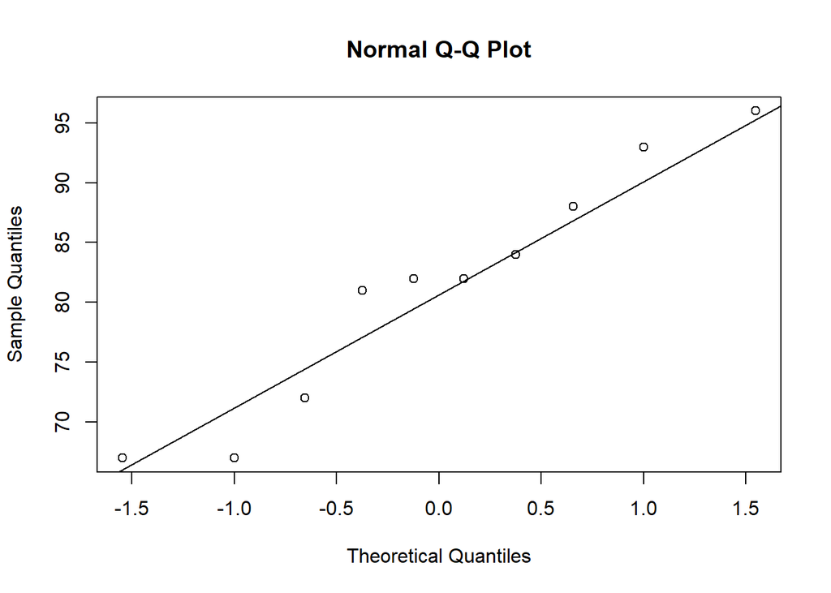

```r
temp=c(81,72,67,88,93,96,84,82,82,67)
qqnorm(temp)
qqline(temp)
```

This looks fine for normality

$$n=10,\bar X=81.20,S=10.01\\
t_{9,0.05}=qt(0.95,9)=1.833\\
ME=1.833\times{10.01\over\sqrt{10}}=5.80\\
81.20\pm5.8=[75.4,87.00]$$

Interpretation:

We are 90% confident that the average temperature in New York in Sep. 1973 is between 75.4 and 87.00 degree.

We can obtain T confidence intervals in R:

```r
confint(lm(temp ~ 1),level =0.9)
```

```
##                  5 %     95 %
## (Intercept) 75.39804 87.00196
```

```r
# lm stands for linear model, level is the confidence interval. 90% in this case)
```

Precision

For means, the margin of error is

$$MOE=z_{\alpha/2}{\sigma\over \sqrt{n}}~ or~ MOE=t_{n-1,\alpha/2} {S\over
\sqrt{n}}$$

L is the desired length of Confidence Interval.

$L=2\times z_{\alpha/2}\times {\sigma\over \sqrt{n}}\to n=(2\times z_{\alpha/2}\times {\sigma\over L})^2$

To make the confidence interval shorter, we can increase the sample size.

Choose n so that

$$n\geq(2z_{\alpha/2}{S_{pr}\over L})^2$$

- $S_{pr}$ is a preliminary estimate of $\sigma$.

Note: Often a preliminary estimate of $\sigma$ is not available.

1. Guess a likely range of values that the variable will take.
2. Use $S_{pr}={range\over 3.5}$ (if uniform) $S_{pr}={range\over 4}$ (is normal)

Example: What sample size should we use to obtain a 90% confidence interval of length 5 for the average temperature in New York in 1973?

$$L=5, S_{pr}=10.01,z_{\alpha/2}=qnorm(0.95)=1.645\\
n\geq[2\times 1.645\times{0.01\over 5}]^2=43.38=44$$

Always round up.

### Confidence Intervals for the Variance

Example: Suppose we want a confidence interval for the variance in temperature in New York in 1973.

$\sigma^2$= true variance, $S^2$= sample variance to estimate $\sigma^2$

It turns out that if the population has a normal distribution

$${(n-1)S^2\over \sigma^2}\sim\chi^2_{n-1}$$

#### The chi-square Distribution

If $Z_1,...,Z_n$ are iid with $N(0,1)$ then $Z_1^2,...,Z_n^2\sim \chi_n^2$.

- $X\sim \chi_v^2$ has the $\chi^2$ distribution with v degrees of freedom
- Plot of $\chi_v^2$ densities:
  - Positive support
  - Non-symmetric

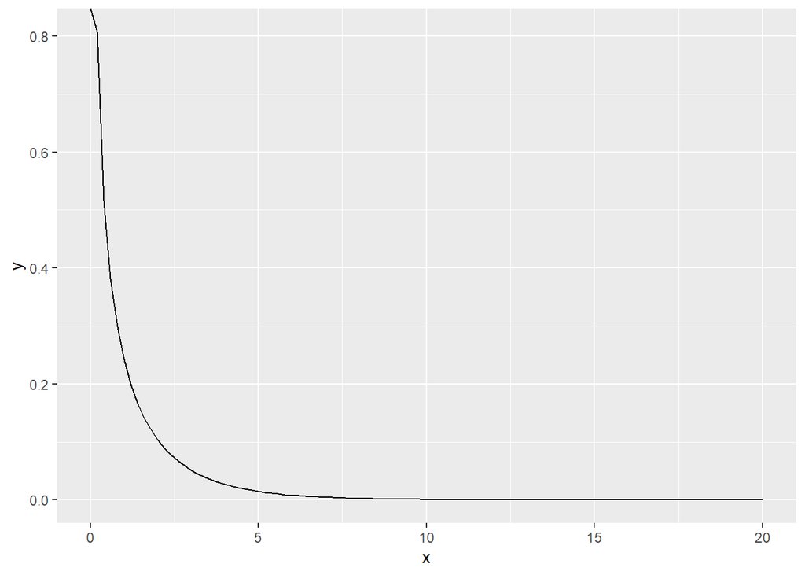

```r
library(ggplot2)

ggplot(data.frame(x = c(0, 20)), aes(x = x)) +
     stat_function(fun = dchisq, args = list(df = 1))
```

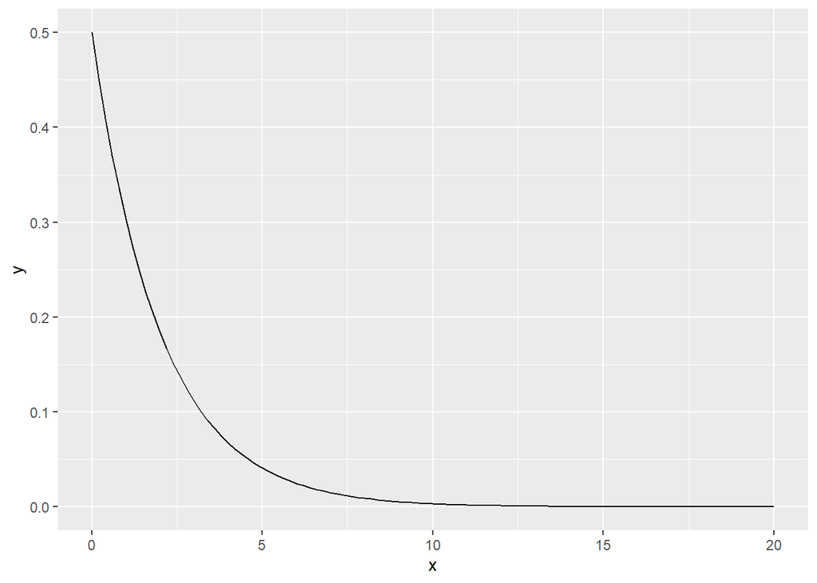

```r
ggplot(data.frame(x = c(0, 20)), aes(x = x)) +
     stat_function(fun = dchisq, args = list(df = 2))
```

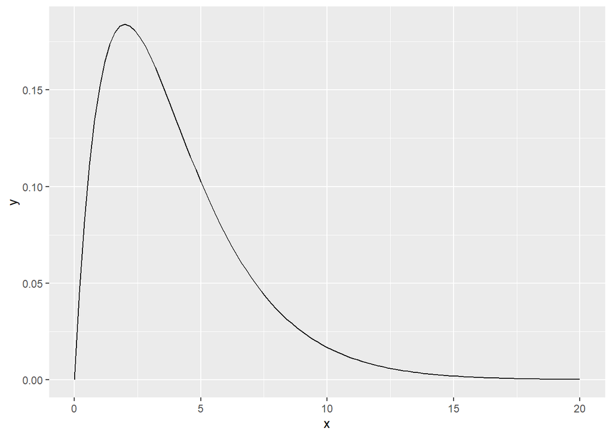

```r
ggplot(data.frame(x = c(0, 20)), aes(x = x)) +
     stat_function(fun = dchisq, args = list(df = 4))
```

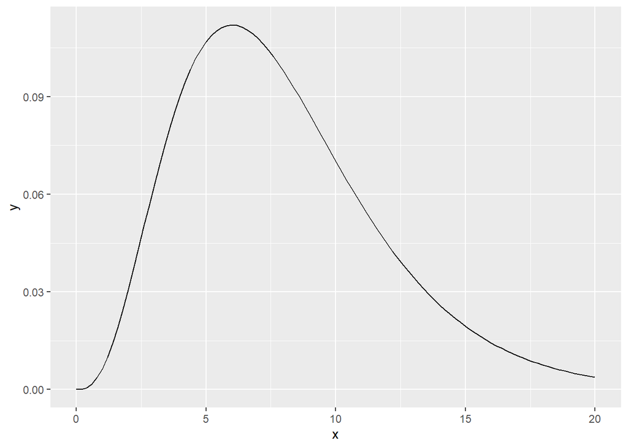

```r
ggplot(data.frame(x = c(0, 20)), aes(x = x)) +
     stat_function(fun = dchisq, args = list(df = 8))
```

#### Confidence Interval

A $(1-\alpha)100\%$ confidence interval for $\sigma^2$ is

$${(n-1)S^2\over \chi_{n-1,\alpha/2}^2}<\sigma^2<{(n-1)S^2\over
\chi_{n-1,1-\alpha/2}^2}$$

percentiles for the $\chi^2$ distribution can be found in R:

`qchisq(p, v)` gives $\chi^2_{v,1-p}$